# Homework 3

## Dataset

I decided to use a churn dataset for this task - the same one as in Homework 1. It is a dataset relating characteristics of telephony account features and usage and whether or not the customer churned.

## Selected observations decomposition

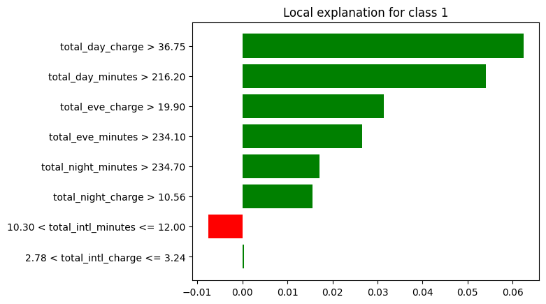

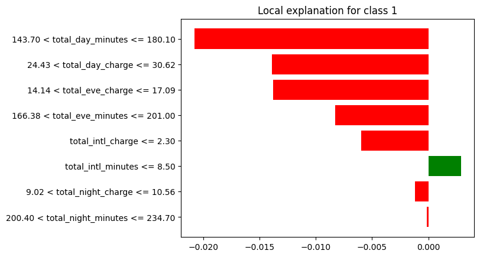

## Stability assessment

From plots showing LIME behavior for different seeds it is clear that algorithm is not completely stable. However, the most important features stay the same even if their impact on prediction varies.

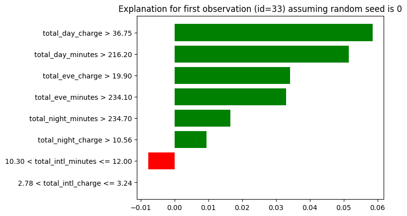

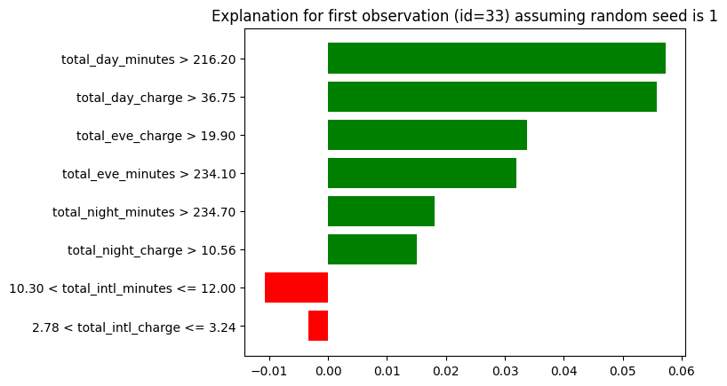

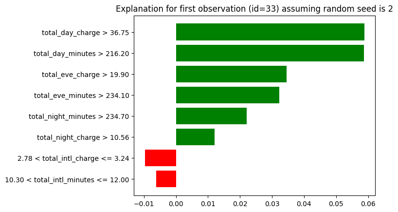

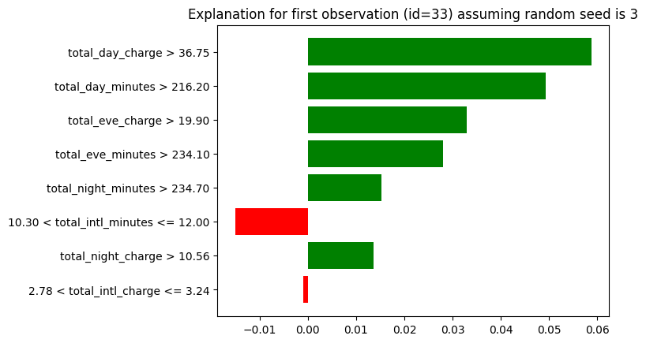

## LIME comparison for random forest and logistic regression

For comparison I use the same model as in the Homework 1 - logistic regression. LIME shows that regression model uses total_day_minutes as a top predictor but it also looks at some other variables like total_intl_minutes, total_eve_minutes or total_night_minutes.

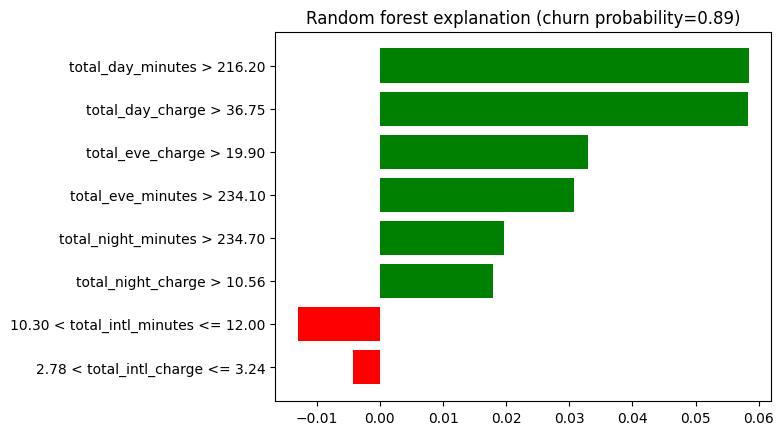

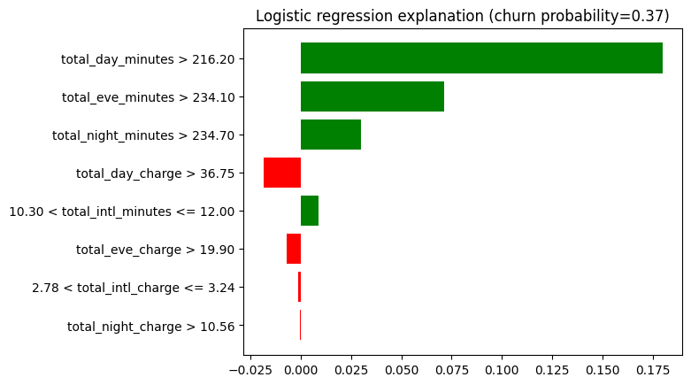

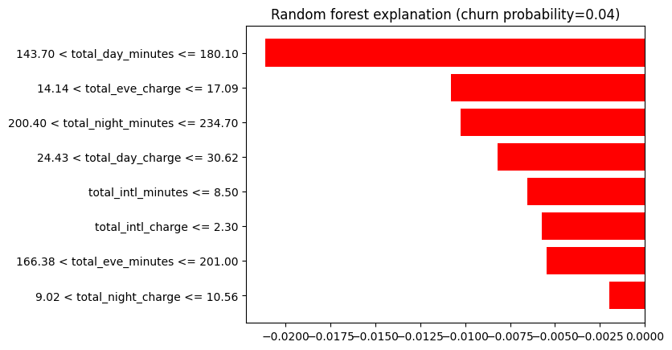

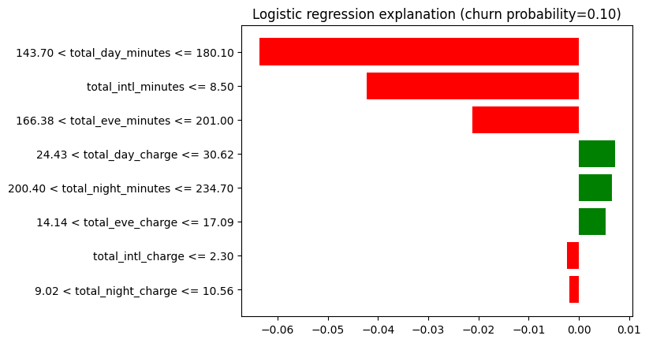

# Appendix

```python
import random
import dalex as dx
import numpy as np
import pandas as pd
import matplotlib.pyplot as plt
```

```python
data = pd.read_csv("datasets/churn.csv", index_col=0)
print(f'Dataset has {data.shape[0]} rows and {data.shape[1]} columns')
display(data.head())

x, y = data.drop(columns='TARGET'), data.TARGET
```

```
Dataset has 5000 rows and 9 columns
```

|  | total_day_minutes | total_day_charge | total_eve_minutes | total_eve_charge | total_night_minutes | total_night_charge | total_intl_minutes | total_intl_charge | TARGET |
| --- | --- | --- | --- | --- | --- | --- | --- | --- | --- |
| 0 | 265.1 | 45.07 | 197.4 | 16.78 | 244.7 | 11.01 | 10.0 | 2.70 | 0 |
| 1 | 161.6 | 27.47 | 195.5 | 16.62 | 254.4 | 11.45 | 13.7 | 3.70 | 0 |
| 2 | 243.4 | 41.38 | 121.2 | 10.30 | 162.6 | 7.32 | 12.2 | 3.29 | 0 |
| 3 | 299.4 | 50.90 | 61.9 | 5.26 | 196.9 | 8.86 | 6.6 | 1.78 | 0 |
| 4 | 166.7 | 28.34 | 148.3 | 12.61 | 186.9 | 8.41 | 10.1 | 2.73 | 0 |

```python
from sklearn.ensemble import RandomForestClassifier

randomForest = RandomForestClassifier().fit(x, y)
randomForestExplainer = dx.Explainer(randomForest, x, y)
```

[output not shown]

## 1. Calculate predictions for selected observations

```python
randomForest.predict_proba(x)
```

```
array([[0.85, 0.15],
       [0.9 , 0.1 ],
       [0.98, 0.02],
       ...,
       [0.95, 0.05],
       [0.99, 0.01],
       [0.95, 0.05]])
```

```python
selected_x = x.loc[[33, 34], :]
obs1, obs2 = selected_x.iloc[0], selected_x.iloc[1]
randomForest.predict_proba(selected_x)
```

```
array([[0.11, 0.89],
       [0.96, 0.04]])
```

## 2. Decompose selected predictions

|  | variable | effect |
| --- | --- | --- |
| 0 | total_day_charge > 36.75 | 0.062354 |
| 1 | total_day_minutes > 216.20 | 0.053992 |
| 2 | total_eve_charge > 19.90 | 0.031414 |
| 3 | total_eve_minutes > 234.10 | 0.026644 |
| 4 | total_night_minutes > 234.70 | 0.017142 |
| 5 | total_night_charge > 10.56 | 0.015623 |
| 6 | 10.30 < total_intl_minutes <= 12.00 | -0.007589 |
| 7 | 2.78 < total_intl_charge <= 3.24 | 0.000439 |

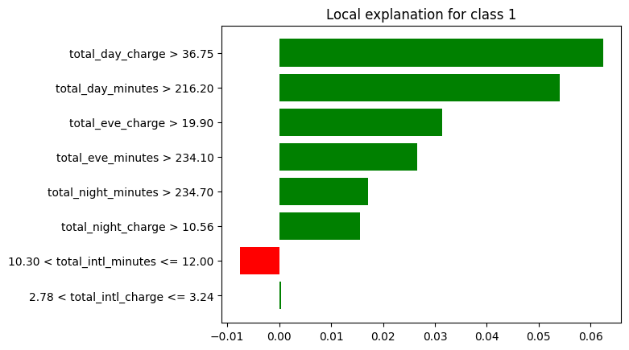

```python
explanation1 = randomForestExplainer.predict_surrogate(obs1)
display(explanation1.result)
explanation1.plot()
```

|  | variable | effect |
| --- | --- | --- |
| 0 | 143.70 < total_day_minutes <= 180.10 | -0.020789 |
| 1 | 24.43 < total_day_charge <= 30.62 | -0.013892 |
| 2 | 14.14 < total_eve_charge <= 17.09 | -0.013793 |
| 3 | 166.38 < total_eve_minutes <= 201.00 | -0.008261 |
| 4 | total_intl_charge <= 2.30 | -0.005939 |
| 5 | total_intl_minutes <= 8.50 | 0.002889 |
| 6 | 9.02 < total_night_charge <= 10.56 | -0.001202 |
| 7 | 200.40 < total_night_minutes <= 234.70 | -0.000153 |

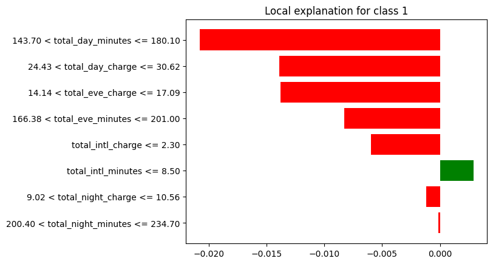

```python
explanation2 = randomForestExplainer.predict_surrogate(obs2)
display(explanation2.result)
explanation2.plot()
```

## 3. Check explanation stability

Check explanation stability only for the first observation.

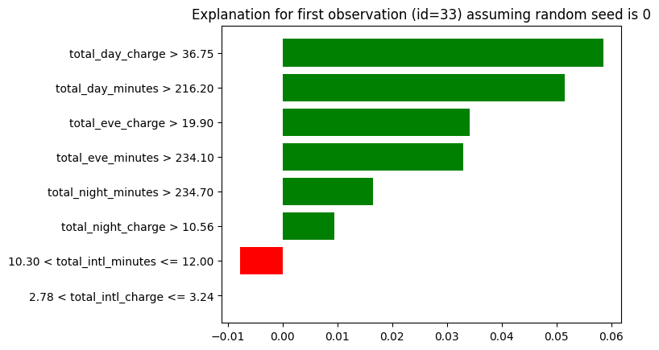

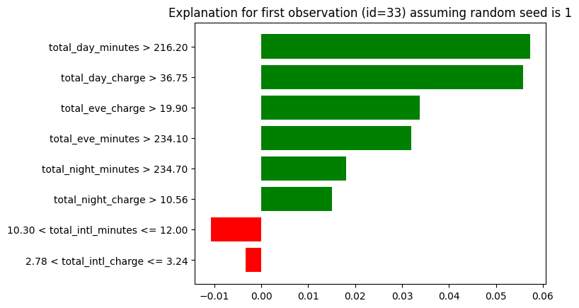

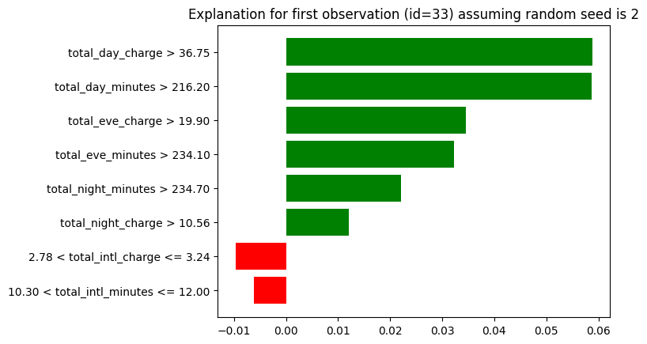

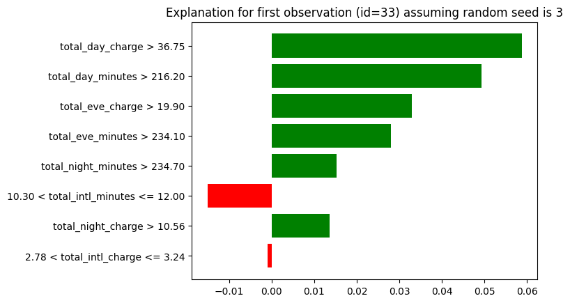

```python
for seed in range(4):
    random.seed(seed)
    np.random.seed(seed)
    exp = randomForestExplainer.predict_surrogate(obs1)
    exp.plot(return_figure=True)
    plt.title(f'Explanation for first observation (id=33) assuming random seed is {seed}')
```

## 5. Compare LIME for random forest and logistic regression

```python
from sklearn.linear_model import LogisticRegression

logisticRegression = LogisticRegression().fit(x, y)
logisticRegressionExplainer = dx.Explainer(logisticRegression, x, y)
```

[output not shown]

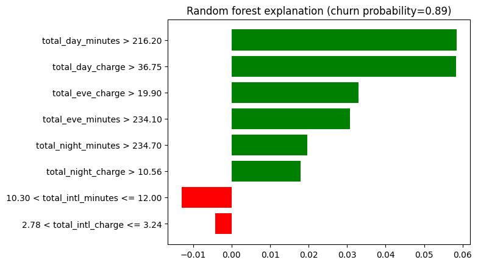

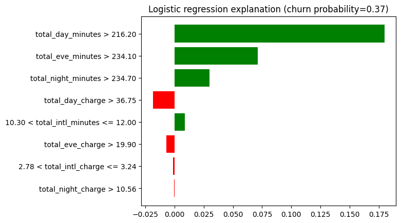

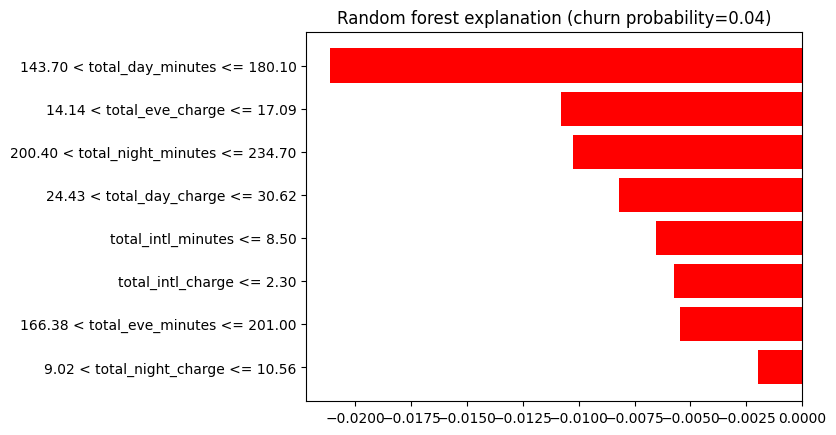

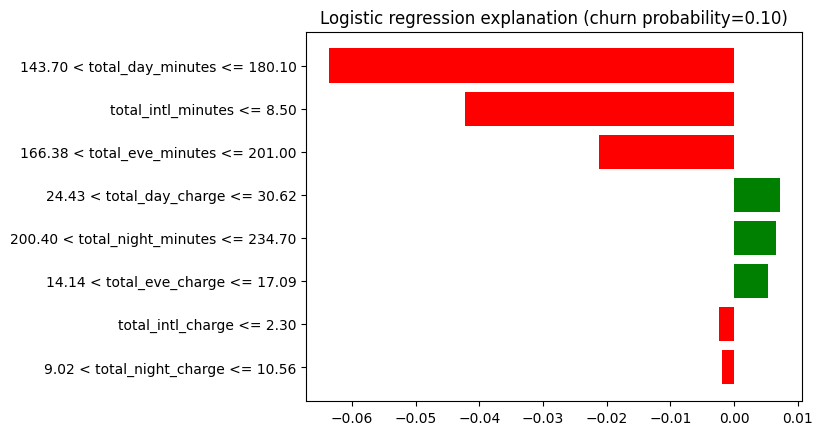

```python
forest_proba = randomForest.predict_proba(selected_x)
reg_proba = logisticRegression.predict_proba(selected_x)

for i in range(selected_x.shape[0]):
    exp_forest = randomForestExplainer.predict_surrogate(selected_x.iloc[i])
    exp_forest.plot(return_figure=True)
    plt.title(f"Random forest explanation (churn probability={forest_proba[i, 1]})")

    exp_reg = logisticRegressionExplainer.predict_surrogate(selected_x.iloc[i])
    exp_reg.plot(return_figure=True)
    plt.title(f"Logistic regression explanation (churn probability={reg_proba[i, 1]:.2f})")
```